# R Notebook

```r
library(tidyverse)
library(janitor)
```

# 1 MVP

The file project_management.csv contains data sampled from the recent work schedule of a small construction company. Column estimated_length contains the estimated length of a building job in days, while column actual_length contains the actual recorded length of the job in days.

We are interested in determining the accuracy of the job estimations made by the company using simple linear regression, so we will eventually want to run a simple linear regression using actual_length as the dependent variable, and estimated_length as the independent variable.

# Load the data into a dataframe project

```r
pro_man <- read_csv("project_management.csv")
pro_man
```

| ...1 | estimated_length | actual_length |
| --- | --- | --- |
| 1 | 12 | 17 |
| 2 | 16 | 22 |
| 3 | 16 | 23 |
| 4 | 18 | 25 |
| 5 | 22 | 39 |
| 6 | 19 | 24 |
| 7 | 18 | 24 |
| 8 | 18 | 21 |
| 9 | 18 | 23 |
| 10 | 15 | 20 |

[output cut: 40 more lines]

# Plot the data, taking estimated_length as the independent variable and actual_length as the dependent variable.

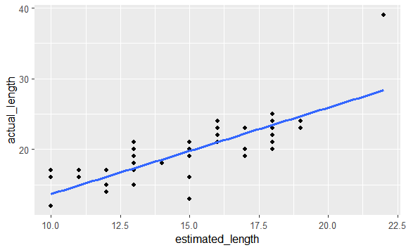

```r
pro_man %>%
  ggplot(aes(x=estimated_length, y = actual_length))+
  geom_point()+
  geom_smooth(method = "lm", se = FALSE)
```

# Calculate the correlation coefficient of estimated_length and actual_length and interpret the value you obtain.

```r
pro_man %>%
  summarise(cor(estimated_length, actual_length))
```

| cor(estimated_length, actual_length) |
| --- |
| 0.8046597 |

*The correlation co-efficient of 0.80 suggests a very strongly positive correlation between the two variables. They are good at estimating the length of a project.*

# Perform a simple linear regression using actual_length as the dependent variable, and estimated_length as the independent variable. Save the model object to a variable.

```r
model <- pro_man %>%
  lm(actual_length ~ estimated_length, .)

model
```

```
Call:
lm(formula = actual_length ~ estimated_length, data = .)

Coefficients:
     (Intercept)  estimated_length
           1.416             1.223
```

# Interpret the regression coefficient of estimated_length (i.e. slope, gradient) you obtain from the model. How do you interpret the r2 value reported by the model?

```r
summary(model)
```

```
Call:
lm(formula = actual_length ~ estimated_length, data = .)

Residuals:
    Min      1Q  Median      3Q     Max
-6.7687 -1.6513  0.1195  1.1252 10.6669

Coefficients:
                 Estimate Std. Error t value Pr(>|t|)
(Intercept)        1.4164     2.0069   0.706    0.484
estimated_length   1.2235     0.1303   9.389 1.91e-12 ***
---
Signif. codes:  0 ‘***’ 0.001 ‘**’ 0.01 ‘*’ 0.05 ‘.’ 0.1 ‘ ’ 1

Residual standard error: 2.606 on 48 degrees of freedom
Multiple R-squared:  0.6475,    Adjusted R-squared:  0.6401
F-statistic: 88.16 on 1 and 48 DF,  p-value: 1.911e-12
```

*r^2 is 0.64, a strong positive correlation*

Is the relationship statistically significant? Remember, to assess this you need to check the p-value of the regression coefficient (or slope/gradient). But you should first check the regression diagnostic plots to see if the p-value will be reliable (don’t worry about any outlier points you see in the diagnostic plots, we’ll return to them in the extension).

*P value was very close to 0 which would suggest a stong linder relationship.* *Residuals Vs fitted and scale location appear fairly flat suggesting model okay. Scale location starts to curl up at the ends which could relate to fewer data points at the ends.* *Normal Q-Q graph appears valid for a straight line fit* *One outlier value in residuals Vs Leverage which is for the one furthest right on the plot (longest job/estimate)* *Histogram is relatively normal but would need more data to flesh out.*

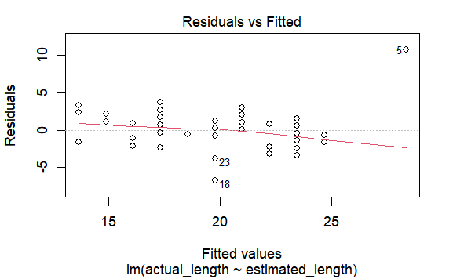

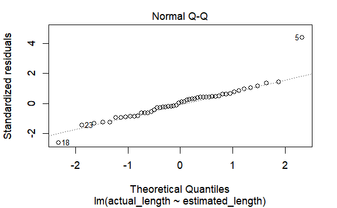

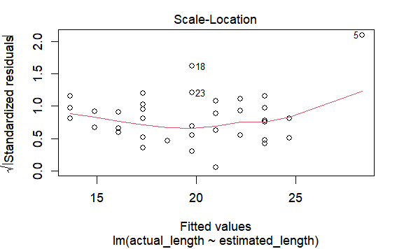

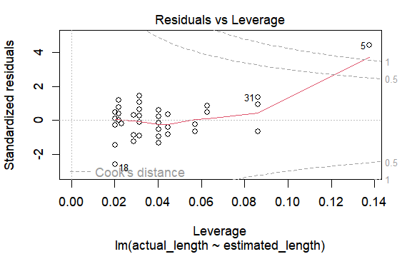

```r
# autoplot(model)
# don't know why that won't go

plot(model)
```

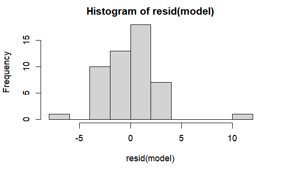

```r
hist(resid(model))
```

# 2 Extension - Residuals vs Leverage

Read this material on the leverage of points in regression, and how to interpret the Residuals vs Leverage diagnostic plot produced by plotting the lm() model object. So far we’ve been using the autoplot() function to plot the model objects produced by lm(), but you can see the base R equivalent by doing something like plot(model) where model is an lm() object.

Return to your plot from earlier, and now label the data points with their row number in the data frame using geom_text() [Hint - you can pass aes(label = 1:nrow(project)) to this layer to generate row index labels] Identify by eye any points you think might be outliers and note their labels. Further split your outliers into those you think are ‘influential’ or ‘non-influential’ based on a visual assessment of their leverage.

*Main outlier is point for row 5*

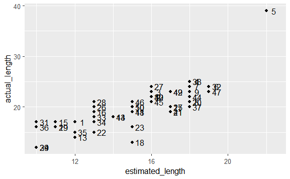

```r
pro_man %>%
  ggplot(aes(x=estimated_length, y = actual_length))+
  geom_point()+
  geom_text(aes(label = 1:nrow(pro_man)), nudge_x = 0.4)
```

Use your model object from earlier and confirm your visual assessment of which points are ‘influential’ or ‘non-influential’ outliers based on Cook’s distance. You can get a useful plot of Cook’s distance by passing argument which = 4 to autoplot(). Or try the base R plot() function for comparison [e.g. plot(model); you can also use par(mfrow = c(2,2)) just before the plot() command to get a nice two-by-two display]!

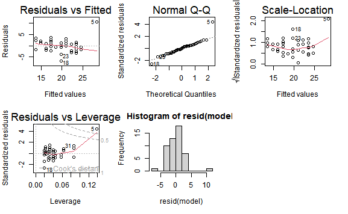

```r
par(mfrow = c(2,3))

plot(model)
hist(resid(model))
```

Obtain the intercept and regression coefficient of variable estimated_length for a simple linear model fitted to data omitting one of your non-influential outlier points. How different are the intercept and coefficient from those obtained above by fitting the full data set? Does this support classifying the omitted point as non-influential? Plot the data points, this regression line and the regression line for the full data set. How different are the lines?

*50 is very central and in trend* *Results barely change, 1.416 ->1.410 and 1.223 -> 1.224*

```r
pro_man %>%
  filter(...1 != 50) %>%
  summarise(cor(estimated_length, actual_length))
```

| cor(estimated_length, actual_length) |
| --- |
| 0.8046955 |

```r
model_2 <- pro_man %>%
  filter(...1 != 50) %>%
  lm(actual_length ~ estimated_length, .)

model_2
```

```
Call:
lm(formula = actual_length ~ estimated_length, data = .)

Coefficients:
     (Intercept)  estimated_length
           1.410             1.224
```

Repeat the procedure above, but this time omitting one of your influential outliers.

*Significant change to results for line plot (1.416 -> 4.381, 1.223 -> 1.011), correlation does not change much (0.804 -> 0.806).*

```r
pro_man %>%
  filter(...1 != 5) %>%
  summarise(cor(estimated_length, actual_length))
```

| cor(estimated_length, actual_length) |
| --- |
| 0.8060756 |

```r
model_3 <- pro_man %>%
  filter(...1 != 5) %>%
  lm(actual_length ~ estimated_length, .)

model_3
```

```
Call:
lm(formula = actual_length ~ estimated_length, data = .)

Coefficients:
     (Intercept)  estimated_length
           4.381             1.011
```